# Assignment 3 - Text Mining

## Text Mining

### Question 1

First, I counted the number of abstracts associated with each PubMed search term.

```r
abstract_counts <- pubmed |>
  count(term, name = "number_of_abstracts") |>
  arrange(desc(number_of_abstracts))

abstract_counts |>
  kable(
    col.names = c("Search term", "Number of abstracts"),
    caption = "Number of abstracts associated with each search term"
  )
```

Number of abstracts associated with each search term

| Search term | Number of abstracts |
| --- | --- |
| covid | 981 |
| prostate cancer | 787 |
| preeclampsia | 780 |
| cystic fibrosis | 376 |
| meningitis | 317 |

There are 3241 abstracts with nonmissing text in the dataset. The search term with the largest number of abstracts is **covid**, with 981 abstracts.

I next tokenized each abstract into individual words and counted the frequency of every token.

```r
abstract_tokens <- pubmed |>
  select(abstract_id, term, abstract) |>
  unnest_tokens(word, abstract) |>
  filter(
    !is.na(word),
    str_detect(word, "[a-zA-Z]")
  )

token_counts <- abstract_tokens |>
  count(term, word, sort = TRUE)

top5_raw <- token_counts |>
  group_by(term) |>
  slice_max(order_by = n, n = 5, with_ties = FALSE) |>
  arrange(term, desc(n)) |>
  ungroup()

top5_raw |>
  kable(
    col.names = c("Search term", "Token", "Count"),
    caption = "Five most common tokens for each search term"
  )
```

Five most common tokens for each search term

| Search term | Token | Count |
| --- | --- | --- |
| covid | the | 9741 |
| covid | of | 7668 |
| covid | covid | 7275 |
| covid | and | 6861 |
| covid | in | 4526 |
| cystic fibrosis | the | 2677 |
| cystic fibrosis | of | 2304 |
| cystic fibrosis | and | 1777 |
| cystic fibrosis | in | 1497 |
| cystic fibrosis | to | 1011 |
| meningitis | the | 2489 |
| meningitis | of | 2269 |
| meningitis | and | 1683 |
| meningitis | in | 1322 |
| meningitis | a | 830 |
| preeclampsia | the | 7119 |
| preeclampsia | of | 6837 |
| preeclampsia | and | 5255 |
| preeclampsia | in | 3869 |
| preeclampsia | to | 2651 |
| prostate cancer | the | 6100 |
| prostate cancer | of | 5682 |
| prostate cancer | and | 4417 |
| prostate cancer | cancer | 3840 |
| prostate cancer | prostate | 3832 |

The unfiltered results are dominated by frequently used English words such as articles, conjunctions, and prepositions. These words occur often because of sentence structure, but they provide relatively little information about the scientific subjects of the abstracts. The results demonstrate why stop-word removal is an important preprocessing step in text mining.

### Question 2

I removed common English stop words using the `stop_words` dataset supplied by the `tidytext` package.

```r
tokens_without_stopwords <- abstract_tokens |>
  anti_join(stop_words, by = "word")

clean_token_counts <- tokens_without_stopwords |>
  count(term, word, sort = TRUE)

top5_clean <- clean_token_counts |>
  group_by(term) |>
  slice_max(order_by = n, n = 5, with_ties = FALSE) |>
  arrange(term, desc(n)) |>
  ungroup()

top5_clean |>
  kable(
    col.names = c("Search term", "Token", "Count"),
    caption = paste(
      "Five most common tokens for each search term after removing",
      "stop words"
    )
  )
```

Five most common tokens for each search term after removing stop words

| Search term | Token | Count |
| --- | --- | --- |
| covid | covid | 7275 |
| covid | patients | 2293 |
| covid | disease | 943 |
| covid | pandemic | 800 |
| covid | coronavirus | 647 |
| cystic fibrosis | fibrosis | 867 |
| cystic fibrosis | cystic | 862 |
| cystic fibrosis | cf | 625 |
| cystic fibrosis | patients | 586 |
| cystic fibrosis | disease | 400 |
| meningitis | patients | 446 |
| meningitis | meningitis | 429 |
| meningitis | meningeal | 219 |
| meningitis | csf | 206 |
| meningitis | clinical | 187 |
| preeclampsia | pre | 2038 |
| preeclampsia | eclampsia | 2005 |
| preeclampsia | preeclampsia | 1863 |
| preeclampsia | women | 1196 |
| preeclampsia | pregnancy | 969 |
| prostate cancer | cancer | 3840 |
| prostate cancer | prostate | 3832 |
| prostate cancer | patients | 934 |
| prostate cancer | treatment | 926 |
| prostate cancer | disease | 652 |

Removing stop words substantially changes the most frequent tokens. The new lists contain more medically and scientifically meaningful terms that reflect the subjects represented by the PubMed searches. The highest-frequency non-stop-word token overall is **covid**, which occurs 7,275 times within the **covid** search group.

### Question 3

I tokenized the abstracts into bigrams, meaning sequences of two consecutive words. I excluded bigrams in which both words were stop words. This retains phrases containing useful content while preventing combinations such as “of the” from dominating the results.

```r
stop_word_vector <- stop_words |>
  distinct(word) |>
  pull(word)

bigram_counts <- pubmed |>
  select(abstract_id, term, abstract) |>
  unnest_tokens(bigram, abstract, token = "ngrams", n = 2) |>
  separate(
    bigram,
    into = c("word1", "word2"),
    sep = " ",
    remove = FALSE
  ) |>
  filter(
    !is.na(word1),
    !is.na(word2),
    str_detect(word1, "[a-zA-Z]"),
    str_detect(word2, "[a-zA-Z]"),
    !(word1 %in% stop_word_vector & word2 %in% stop_word_vector)
  ) |>
  count(bigram, sort = TRUE)

top10_bigrams <- bigram_counts |>
  slice_max(order_by = n, n = 10, with_ties = FALSE)

top10_bigrams |>
  kable(
    col.names = c("Bigram", "Count"),
    caption = "Ten most common bigrams"
  )
```

Ten most common bigrams

| Bigram | Count |
| --- | --- |
| prostate cancer | 3222 |
| pre eclampsia | 1854 |
| patients with | 1587 |
| of covid | 1519 |
| of prostate | 870 |
| cystic fibrosis | 860 |
| the covid | 706 |
| of pre | 604 |
| of preeclampsia | 578 |
| with covid | 576 |

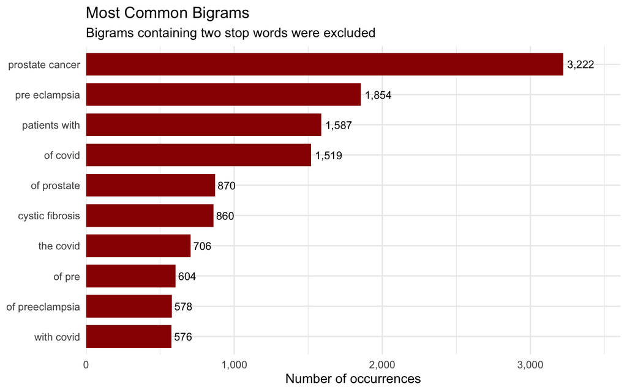

Ten most common bigrams in the PubMed abstracts

```r
top10_bigrams |>
  mutate(bigram = fct_reorder(bigram, n)) |>
  ggplot(aes(x = n, y = bigram)) +
  geom_col(fill = "#990000", width = 0.75) +
  geom_text(
    aes(label = comma(n)),
    hjust = -0.15,
    size = 3.5
  ) +
  scale_x_continuous(
    labels = comma,
    expand = expansion(mult = c(0, 0.12))
  ) +
  labs(
    title = "Most Common Bigrams",
    subtitle = "Bigrams containing two stop words were excluded",
    x = "Number of occurrences",
    y = NULL
  )
```

The most frequent bigram is **“prostate cancer”**, appearing 3,222 times. In contrast to the single-token analysis, the bigram analysis provides context by showing which words commonly occur together.

### Question 4

For the TF-IDF analysis, each search term was treated as a document. Term frequency measures how frequently a token appears within a search term, while inverse document frequency gives greater weight to tokens that are uncommon across the other search terms.

```r
tf_idf_results <- clean_token_counts |>
  bind_tf_idf(
    term = word,
    document = term,
    n = n
  )

top5_tf_idf <- tf_idf_results |>
  group_by(term) |>
  slice_max(order_by = tf_idf, n = 5, with_ties = FALSE) |>
  arrange(term, desc(tf_idf)) |>
  ungroup()

top5_tf_idf |>
  select(term, word, n, tf, idf, tf_idf) |>
  mutate(
    tf = round(tf, 5),
    idf = round(idf, 5),
    tf_idf = round(tf_idf, 5)
  ) |>
  kable(
    col.names = c(
      "Search term",
      "Token",
      "Count",
      "Term frequency",
      "Inverse document frequency",
      "TF-IDF"
    ),
    caption = "Five tokens with the highest TF-IDF for each search term"
  )
```

Five tokens with the highest TF-IDF for each search term

| Search term | Token | Count | Term frequency | Inverse document frequency | TF-IDF |
| --- | --- | --- | --- | --- | --- |
| covid | covid | 7275 | 0.07362 | 1.60944 | 0.11849 |
| covid | pandemic | 800 | 0.00810 | 1.60944 | 0.01303 |
| covid | coronavirus | 647 | 0.00655 | 1.60944 | 0.01054 |
| covid | sars | 372 | 0.00376 | 1.60944 | 0.00606 |
| covid | cov | 334 | 0.00338 | 1.60944 | 0.00544 |
| cystic fibrosis | cf | 625 | 0.02436 | 0.91629 | 0.02232 |
| cystic fibrosis | fibrosis | 867 | 0.03379 | 0.51083 | 0.01726 |
| cystic fibrosis | cystic | 862 | 0.03359 | 0.51083 | 0.01716 |
| cystic fibrosis | cftr | 86 | 0.00335 | 1.60944 | 0.00539 |
| cystic fibrosis | sweat | 83 | 0.00323 | 1.60944 | 0.00521 |
| meningitis | meningitis | 429 | 0.01744 | 1.60944 | 0.02807 |
| meningitis | meningeal | 219 | 0.00890 | 1.60944 | 0.01433 |
| meningitis | pachymeningitis | 149 | 0.00606 | 1.60944 | 0.00975 |
| meningitis | csf | 206 | 0.00837 | 0.91629 | 0.00767 |
| meningitis | meninges | 106 | 0.00431 | 1.60944 | 0.00693 |
| preeclampsia | eclampsia | 2005 | 0.02733 | 1.60944 | 0.04399 |
| preeclampsia | preeclampsia | 1863 | 0.02540 | 1.60944 | 0.04088 |
| preeclampsia | pregnancy | 969 | 0.01321 | 0.51083 | 0.00675 |
| preeclampsia | maternal | 797 | 0.01087 | 0.51083 | 0.00555 |
| preeclampsia | gestational | 191 | 0.00260 | 1.60944 | 0.00419 |
| prostate cancer | prostate | 3832 | 0.05809 | 1.60944 | 0.09350 |
| prostate cancer | androgen | 305 | 0.00462 | 1.60944 | 0.00744 |
| prostate cancer | psa | 282 | 0.00428 | 1.60944 | 0.00688 |
| prostate cancer | prostatectomy | 215 | 0.00326 | 1.60944 | 0.00525 |
| prostate cancer | castration | 148 | 0.00224 | 1.60944 | 0.00361 |

The Question 1 results emphasize tokens that occur frequently, even if those tokens are common across several search groups. In comparison, TF-IDF emphasizes tokens that are both important within one search term and relatively uncommon in the other search terms. Therefore, the TF-IDF results are more useful for identifying words that distinguish one collection of abstracts from another.

## Sentiment Analysis

### Question 5

I used the NRC lexicon to classify words into the sentiments anger, anticipation, disgust, fear, joy, sadness, surprise, and trust, as well as the broader positive and negative categories.

```r
nrc_lexicon <- get_sentiments("nrc")

nrc_counts <- tokens_without_stopwords |>
  inner_join(nrc_lexicon, by = "word") |>
  count(term, sentiment, sort = TRUE)

most_common_nrc <- nrc_counts |>
  group_by(term) |>
  slice_max(order_by = n, n = 1, with_ties = FALSE) |>
  arrange(term) |>
  ungroup()

most_common_nrc |>
  kable(
    col.names = c("Search term", "Most common sentiment", "Count"),
    caption = "Most common NRC sentiment for each search term"
  )
```

Most common NRC sentiment for each search term

| Search term | Most common sentiment | Count |
| --- | --- | --- |
| covid | positive | 9254 |
| cystic fibrosis | positive | 2564 |
| meningitis | negative | 1959 |
| preeclampsia | positive | 7603 |
| prostate cancer | negative | 8799 |

When all NRC categories are retained, broad classifications such as positive or negative may be the most frequent because they apply to a large number of words. I therefore repeated the comparison after removing those two categories.

```r
nrc_emotion_counts <- nrc_counts |>
  filter(!sentiment %in% c("positive", "negative"))

most_common_emotion <- nrc_emotion_counts |>
  group_by(term) |>
  slice_max(order_by = n, n = 1, with_ties = FALSE) |>
  arrange(term) |>
  ungroup()

most_common_emotion |>
  kable(
    col.names = c("Search term", "Most common emotion", "Count"),
    caption = paste(
      "Most common NRC sentiment after excluding positive and negative"
    )
  )
```

Most common NRC sentiment after excluding positive and negative

| Search term | Most common emotion | Count |
| --- | --- | --- |
| covid | fear | 7373 |
| cystic fibrosis | disgust | 1714 |
| meningitis | fear | 1371 |
| preeclampsia | anticipation | 4555 |
| prostate cancer | fear | 8039 |

Removing the positive and negative categories provides a more specific description of the emotions associated with the language in each group. The table shows which of the eight remaining NRC emotions is most common for each search term.

The following visualization displays all eight specific emotion categories.

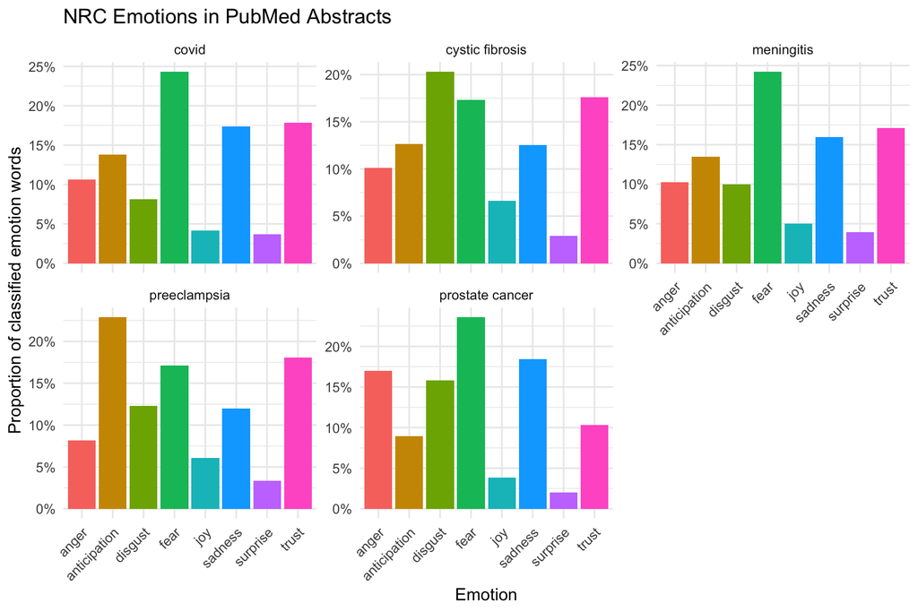

Distribution of NRC emotion categories by search term

```r
nrc_emotion_counts |>
  group_by(term) |>
  mutate(proportion = n / sum(n)) |>
  ungroup() |>
  ggplot(
    aes(
      x = sentiment,
      y = proportion,
      fill = sentiment
    )
  ) +
  geom_col(show.legend = FALSE) +
  facet_wrap(~term, scales = "free_y") +
  scale_y_continuous(labels = percent_format()) +
  labs(
    title = "NRC Emotions in PubMed Abstracts",
    x = "Emotion",
    y = "Proportion of classified emotion words"
  ) +
  theme(
    axis.text.x = element_text(angle = 45, hjust = 1)
  )
```

### Question 6

Finally, I used the AFINN lexicon. AFINN assigns sentiment words integer scores ranging from negative values for negative words to positive values for positive words. I calculated the mean AFINN score among matched sentiment words in each abstract.

```r
afinn_url <- paste0(
  "https://raw.githubusercontent.com/",
  "fnielsen/afinn/master/afinn/data/AFINN-111.txt"
)

afinn_lexicon <- read_tsv(
  afinn_url,
  col_names = c("word", "value"),
  show_col_types = FALSE
)

abstract_afinn <- abstract_tokens |>
  inner_join(afinn_lexicon, by = "word") |>
  group_by(abstract_id, term) |>
  summarise(
    average_positivity = mean(value),
    matched_words = n(),
    .groups = "drop"
  )

afinn_summary <- abstract_afinn |>
  group_by(term) |>
  summarise(
    abstracts_with_scored_words = n(),
    mean_score = mean(average_positivity),
    median_score = median(average_positivity),
    standard_deviation = sd(average_positivity),
    .groups = "drop"
  ) |>
  arrange(desc(median_score))

afinn_summary |>
  mutate(
    mean_score = round(mean_score, 3),
    median_score = round(median_score, 3),
    standard_deviation = round(standard_deviation, 3)
  ) |>
  kable(
    col.names = c(
      "Search term",
      "Abstracts with scored words",
      "Mean score",
      "Median score",
      "Standard deviation"
    ),
    caption = "Summary of average AFINN positivity scores"
  )
```

Summary of average AFINN positivity scores

| Search term | Abstracts with scored words | Mean score | Median score | Standard deviation |
| --- | --- | --- | --- | --- |
| cystic fibrosis | 357 | 0.322 | 0.500 | 1.186 |
| preeclampsia | 769 | -0.121 | -0.143 | 0.918 |
| covid | 958 | -0.147 | -0.160 | 0.990 |
| meningitis | 292 | -0.163 | -0.211 | 1.183 |
| prostate cancer | 787 | -0.239 | -0.250 | 0.543 |

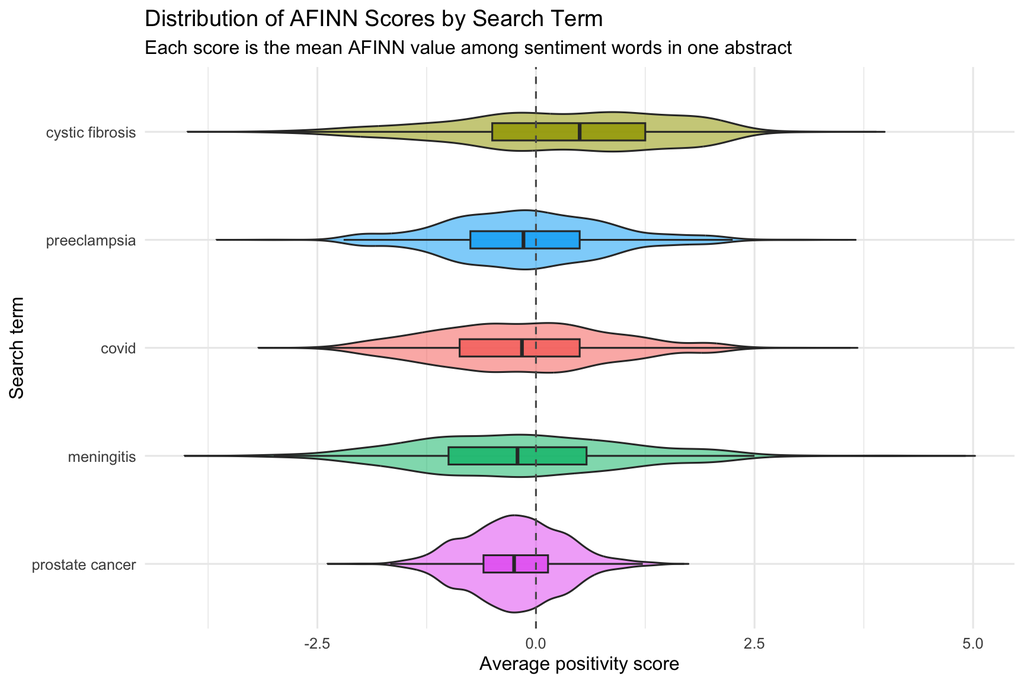

Average AFINN positivity score for each abstract, grouped by search term

```r
abstract_afinn |>
  ggplot(
    aes(
      x = fct_reorder(term, average_positivity, .fun = median),
      y = average_positivity,
      fill = term
    )
  ) +
  geom_violin(
    alpha = 0.55,
    trim = FALSE,
    show.legend = FALSE
  ) +
  geom_boxplot(
    width = 0.16,
    outlier.shape = NA,
    alpha = 0.85,
    show.legend = FALSE
  ) +
  geom_hline(
    yintercept = 0,
    linetype = "dashed",
    color = "gray35"
  ) +
  coord_flip() +
  labs(
    title = "Distribution of AFINN Scores by Search Term",
    subtitle = paste(
      "Each score is the mean AFINN value among sentiment words",
      "in one abstract"
    ),
    x = "Search term",
    y = "Average positivity score"
  )
```

The group with the highest median positivity score is **cystic fibrosis**, with a median score of 0.5. The group with the lowest median score is **prostate cancer**, with a median score of -0.25.

The violin and box plots show both the centers and the distributions of the scores. Search terms whose boxes and median lines are noticeably higher or lower than those of the other groups have different sentiment patterns. However, these scores describe the language used in the abstracts and should not be interpreted as direct measurements of the authors’ emotions.